# Introduction to Matplotlib

To make necessary statistical interpretations, it becomes necessary to visualize your data and `matplotlib` is one such solution for the Python users. It is a very powerful plotting library useful for those working with Python and NumPy. The most used module of `matplotib` is `pyplot` which provides an interface like MATLAB but instead, it uses Python and it is open source.

Some of the major Pros of Matplotlib are:

- Generally easy to get started for simple plots
- Support for custom labels and texts
- Great control of every element in a figure
- High-quality output in many formats
- Very customizable in general

```python
# !pip install matplotlib
```

```python
import matplotlib.pyplot as plt
```

You'll also need to use this line to see plots in the notebook:

```python
%matplotlib inline
```

That line is only for jupyter notebooks, if you are using another editor, you'll use: **plt.show()** at the end of all your plotting commands to have the figure pop up in another window.

### Basic Example

Let's walk through a very simple example using two numpy arrays:

You can also use lists, but most likely you'll be passing numpy arrays or pandas columns (which essentially also behave like arrays).

**The data we want to plot:**

```python
import matplotlib.pyplot as plt
import numpy as np
```

```python
xpoints = np.array([1, 8])
ypoints = np.array([3, 10])

print("x =", xpoints)
print("y =", ypoints)
```

```
x = [1 8]
y = [ 3 10]
```

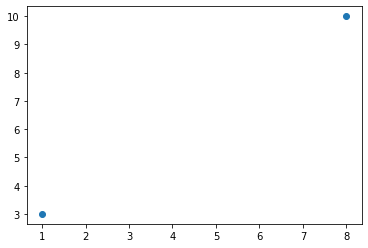

```python
plt.plot(xpoints, ypoints, 'o')
```

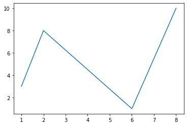

```python
xpoints = np.array([1, 2, 6, 8])
ypoints = np.array([3, 8, 1, 10])

plt.plot(xpoints, ypoints)
plt.show()
```

```python
x = np.linspace(0, 5, 11)
y = x ** 2

print("x =",x)
print("y =",y)
```

```
x = [0.  0.5 1.  1.5 2.  2.5 3.  3.5 4.  4.5 5. ]
y = [ 0.    0.25  1.    2.25  4.    6.25  9.   12.25 16.   20.25 25.  ]
```

We can create a very simple line plot using the following:

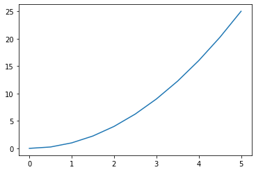

```python
plt.plot(x,y)
plt.show()
```

### Parts of a Figure

Now, let's have a deeper look at the components of a Matplotlib figure.

[figure not shown]

#### Adding Basic Details to plot

```
plt.plot(x, y)
plt.xlabel('X Axis Title Here')
plt.ylabel('Y Axis Title Here')
plt.title('Overall Plot Title Here')
plt.show()
```

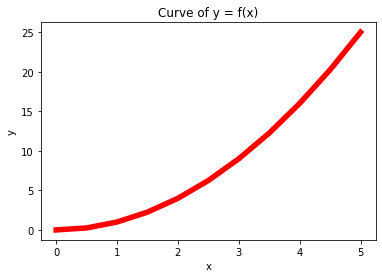

```python
plt.plot(x,y,'r',linewidth = '5.5') # 'r' is the color red; linewidth defines thickness
plt.xlabel('x')
plt.ylabel('y')
plt.title('Curve of y = f(x)')
plt.show()
```

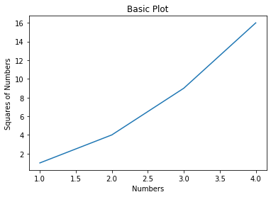

```python
#using lists

plt.plot([1,2,3,4],[1,4,9,16])
plt.title("Basic Plot")
plt.xlabel("Numbers")
plt.ylabel("Squares of Numbers")
plt.show()
```

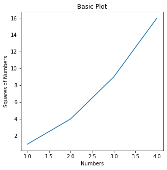

```python
plt.figure(figsize = (5,5))   #setting figure size

plt.plot([1,2,3,4],[1,4,9,16])
plt.title("Basic Plot")
plt.xlabel("Numbers")
plt.ylabel("Squares of Numbers")
plt.show()
```

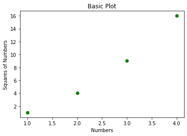

```python
plt.plot([1,2,3,4],[1,4,9,16],"go")   #green dots

plt.title("Basic Plot")
plt.xlabel("Numbers")
plt.ylabel("Squares of Numbers")
plt.show()
```

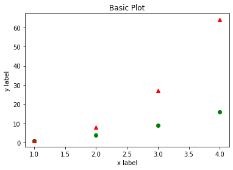

```python
#two line plots

x = np.arange(1,5)
# print(x)
y =  x ** 3
# print(y)

plt.plot([1,2,3,4],[1,4,9,16],"go")  #line 1
plt.plot(x,y,"r^")   #line 2

plt.title("Basic Plot")
plt.xlabel("x label")
plt.ylabel("y label")
plt.show()
```

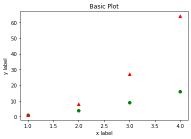

```python
#two line plots

x = np.arange(1,5)
# print(x)
y =  x ** 3
# print(y)

plt.plot([1,2,3,4],[1,4,9,16],"go",x,y,"r^")

plt.title("Basic Plot")
plt.xlabel("x label")
plt.ylabel("y label")
plt.show()
```

**Matplotlib List of Named colors :** https://matplotlib.org/3.1.0/gallery/color/named_colors.html

**Matplotlib Markers Guide:** https://matplotlib.org/3.3.3/api/markers_api.html

**Matplotlib Line-style:** https://matplotlib.org/gallery/lines_bars_and_markers/line_styles_reference.html

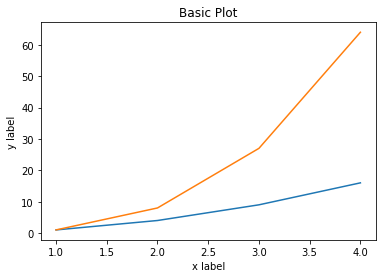

```python
#two line plots

x = np.arange(1,5)
# print(x)
y =  x ** 3
# print(y)

plt.plot([1,2,3,4],[1,4,9,16])
plt.plot(x,y)

plt.title("Basic Plot")
plt.xlabel("x label")
plt.ylabel("y label")
plt.show()
```

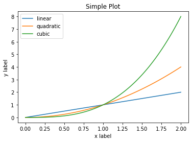

```python
x = np.linspace(0, 2, 100)

plt.plot(x, x, label='linear')  # Plot some data on the (implicit) axes.
plt.plot(x, x**2, label='quadratic')  # etc.
plt.plot(x, x**3, label='cubic')
plt.xlabel('x label')
plt.ylabel('y label')
plt.title("Simple Plot")
plt.legend()
plt.show()
```

### Multiple plots in one figure

The `subplots()` function takes three arguments that describes the layout of the figure.

The layout is organized in rows and columns, which are represented by the first and second argument. The third argument represents the index of the current plot.

The syntax is as follows:

```
subplot(rows,columns,index)
```

where the first two parameters rows and columns indicate the number of rows and columns of a grid. The index position starts at 1 in the upper left corner and increases to the right.

```
plt.subplot(1, 2, 1)
#the figure has 1 row, 2 columns, and this plot is the first plot.

plt.subplot(1, 2, 2)
#the figure has 1 row, 2 columns, and this plot is the second plot.
```

Here is an example:

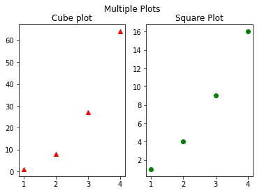

```python
#plot 1
plt.subplot(1,2,1)
plt.plot([1,2,3,4],[1,8,27,64],"r^")
plt.title("Cube plot")

#plot 2
plt.subplot(1,2,2)
plt.plot([1,2,3,4],[1,4,9,16],"go")
plt.title("Square Plot")

plt.suptitle("Multiple Plots")
plt.show()
```

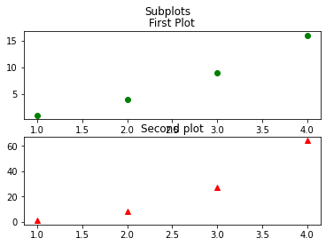

```python
#plot1
plt.subplot(2,1,1)
plt.plot([1,2,3,4],[1,4,9,16],"go")
plt.title("First Plot")

#plot2
plt.subplot(2,1,2)
plt.plot([1,2,3,4],[1,8,27,64],"r^")
plt.title("Second plot")

plt.suptitle("Subplots")
plt.show()
```

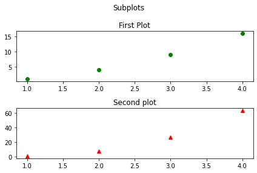

```python
#plot1
plt.subplot(2,1,1)
plt.plot([1,2,3,4],[1,4,9,16],"go")
plt.title("First Plot")

#plot2
plt.subplot(2,1,2)
plt.plot([1,2,3,4],[1,8,27,64],"r^")
plt.title("Second plot")

plt.suptitle("Subplots")
plt.tight_layout()  #fix if your subplots are too squished.
plt.show()
```

#### Another way of `subplot()` indexing:

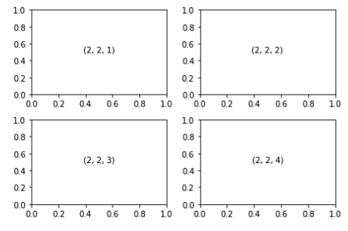

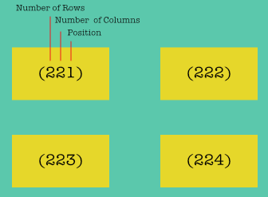

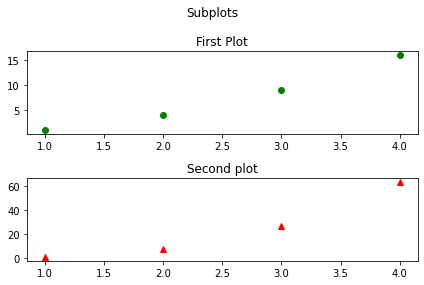

```python
#plot1
plt.subplot(211)
plt.plot([1,2,3,4],[1,4,9,16],"go")
plt.title("First Plot")

#plot2
plt.subplot(212)
plt.plot([1,2,3,4],[1,8,27,64],"r^")
plt.title("Second plot")

plt.suptitle("Subplots")
plt.tight_layout()  #fix if your subplots are too squished.
plt.show()
```

### Plotting vertical and horizontal lines

```python
import matplotlib.pyplot as plt

x =[0, 5, 10, 15, 20]
y =[1, 3, 5, 6, 9]

plt.plot(x, y)
plt.axvline(x = 10,
            linewidth = 2, color ='green') #if we want to draw a vertical line, we have to give x=something.

plt.axvline(x = 15,
            linewidth = 2, color ='red')

plt.show()
```

[output not shown]

```python
import matplotlib.pyplot as plt

x =[0, 5, 10, 15, 20]
y =[1, 3, 5, 6, 9]

plt.plot(x, y)
plt.axhline(y = 8,
            linewidth = 5, color ='red')

plt.show()
```

[output not shown]

# Special Plot Types

There are many specialized plots we can create, such as barplots, histograms, scatter plots, and much more. Most of these type of plots we will actually create using seaborn, a statistical plotting library for Python. But here are a few examples of these type of plots:

## Bar Plot

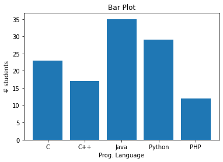

```python
#data
langs = ['C', 'C++', 'Java', 'Python', 'PHP']
students = [23,17,35,29,12]

#plotting barplot
plt.bar(langs,students)
plt.title("Bar Plot")
plt.xlabel("Prog. Language")
plt.ylabel("# students")
plt.show()
```

#### Horizontal Bar Plot

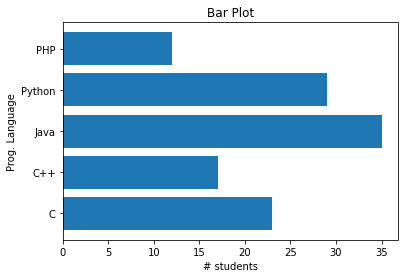

```python
#plotting horizontal barplot

plt.barh(langs,students)
plt.title("Bar Plot")
plt.xlabel("# students")
plt.ylabel("Prog. Language")
plt.show()
```

#### Grouped Bar Plot

The data object is a multidict containing number of students passed in three branches of an engineering college over the last four years. We can plot multiple bar charts by playing with the thickness and the positions of the bars.

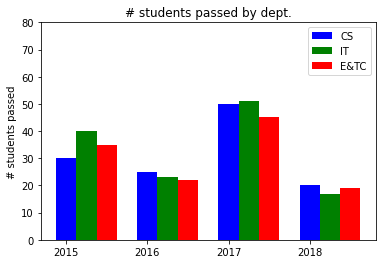

```python
data = [[30, 25, 50, 20],
[40, 23, 51, 17],
[35, 22, 45, 19]]

X = np.arange(4)

#plotting grouped bar chart
plt.bar(X + 0.00, data[0], color = 'b', width = 0.25)
plt.bar(X + 0.25, data[1], color = 'g', width = 0.25)
plt.bar(X + 0.50, data[2], color = 'r', width = 0.25)

#adding details
plt.ylabel('# students passed')
plt.title('# students passed by dept.')
plt.xticks(X, ('2015', '2016', '2017', '2018'))
plt.yticks(np.arange(0, 81, 10))
plt.legend(labels=['CS', 'IT', 'E&TC'])
plt.show()
```

Here, the bars have a thickness of 0.25 units. Each bar chart will be shifted 0.25 units from the previous one.

#### Stacked Bar Plot

The stacked bar chart stacks bars that represent different groups on top of each other. The height of the resulting bar shows the combined result of the groups: 'G1', 'G2', 'G3', 'G4', 'G5'.

`bottom =` allows you to specify a starting value for a bar instead of zero

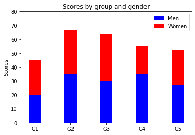

```python
N = 5 #no. of groups consisting men and women
menMeans = (20, 35, 30, 35, 27)    #mean score of men in each group
womenMeans = (25, 32, 34, 20, 25)  #mean score of women in each group

ind = np.arange(N) # the x locations for the groups
width = 0.35

#vertical stacked bar plot
plt.bar(ind, menMeans, width, color='blue')
plt.bar(ind, womenMeans, width,bottom=menMeans, color='red')

# plt.bar(ind, menMeans, width, color='blue',label = 'men')
# plt.bar(ind, womenMeans, width,bottom=menMeans, color='red',label = 'women')

#adding details
plt.ylabel('Scores')
plt.title('Scores by group and gender')
plt.xticks(ind, ('G1', 'G2', 'G3', 'G4', 'G5'))
plt.yticks(np.arange(0, 81, 10))

plt.legend(labels=['Men', 'Women'])
# plt.legend()

plt.show()
```

## Histogram

Following example plots a histogram of marks obtained by students in a class. Four bins, 0-25, 26-50, 51-75, and 76-100 are defined. The Histogram shows number of students falling in this range.

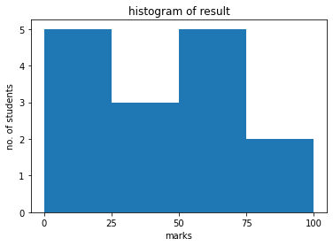

```python
a = np.array([22,87,5,43,56,73,55,54,11,20,51,5,79,31,27])

plt.hist(a, bins = [0,25,50,75,100])

plt.title("histogram of result")
plt.xticks([0,25,50,75,100])
plt.xlabel('marks')
plt.ylabel('no. of students')
plt.show()
```

## Pie Chart

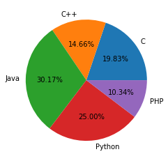

```python
langs = ['C', 'C++', 'Java', 'Python', 'PHP']
students = [23,17,35,29,12]

plt.pie(students, labels = langs,autopct='%1.2f%%') # autopct defines the percentage in sections
plt.show()
```

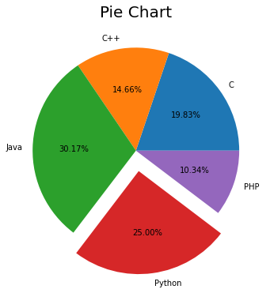

```python
plt.figure(figsize = (6,6))

langs = ['C', 'C++', 'Java', 'Python', 'PHP']
students = [23,17,35,29,12]

explode = [0,0,0,0.2,0]  # for displaying python as a slice of pie

plt.pie(students, explode=explode, labels = langs,autopct='%1.2f%%') # autopct defines the percentage in sections
plt.title("Pie Chart",fontsize = 20)
plt.show()
```

Now you know how to create basic plots using matplotlib, you can begin adding data to the plots in your figure.

Begin by creating a few lists to plot the monthly average precipitation (inches) for Boulder, Colorado provided by the U.S. National Oceanic and Atmospheric Administration (NOAA)

```python
#Creating dataset

# Monthly average precipitation
boulder_monthly_precip = [0.70, 0.75, 1.85, 2.93, 3.05, 2.02,
                          1.93, 1.62, 1.84, 1.31, 1.39, 0.84]

# Month names for plotting
months = ["Jan", "Feb", "Mar", "Apr", "May", "June", "July",
          "Aug", "Sept", "Oct", "Nov", "Dec"]
```

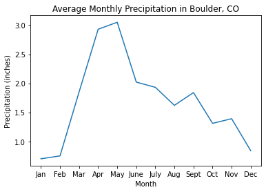

```python
#plotting a line plot
plt.plot(months, boulder_monthly_precip)

plt.title("Average Monthly Precipitation in Boulder, CO")
plt.xlabel("Month")
plt.ylabel("Precipitation (inches)")

plt.show()
```

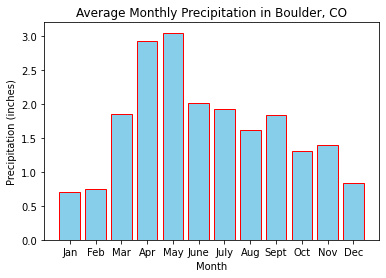

```python
#plotting a line plot
plt.bar(months, boulder_monthly_precip, color = 'skyblue', edgecolor = 'red')

plt.title("Average Monthly Precipitation in Boulder, CO")
plt.xlabel("Month")
plt.ylabel("Precipitation (inches)")

plt.show()
```